# Modelling COVID-19 in Newfoundland and Labrador

Amy Hurford and Steve Walker

18/04/2022

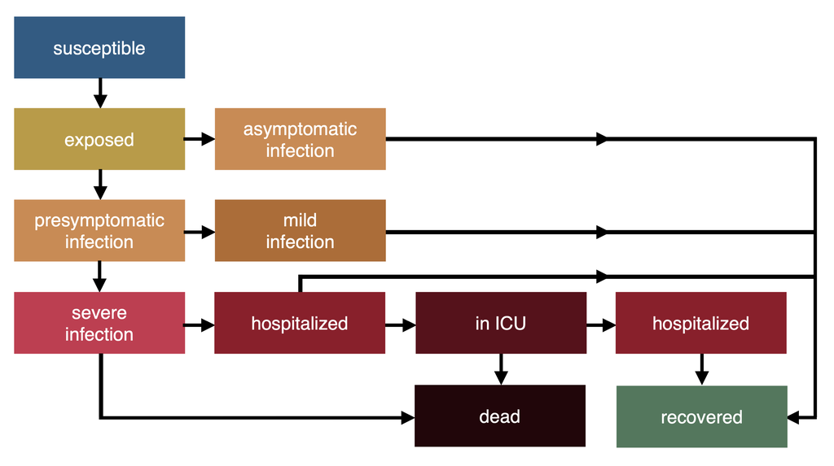

*Diagram by Irena Papst*

Our modelling approach is to fit a [compartmental epidemic model](https://mcmasterpandemic.shinyapps.io/mcmasterpandemicshiny/) to Newfoundland and Labrador COVID-19 data. This approach is used to model COVID-19 in [Ontario](https://mac-theobio.github.io/forecasts/outputs/McMasterOntarioForecastsBlog2022-01-26), however, there are differences in the model formulation for Newfoundland and Labrador.

This modelling approach is mechanistic, or process-based. Process-based modelling contrasts with pattern-based, or phenomenological modelling, which aims to capture the shape of the data and has parameters that do not necessarily have epidemiological interpretations.

To understand what is meant by a *process-based* model, consider some of the model parameters that are fixed, and independent of the Newfoundland and Labrador COVID-19 data. Such parameters may describe epidemiological characteristics that are not region-specific, for example, the recovery rate from infection; or are estimated using other data, for example, the population size of Newfoundland and Labrador, which is estimated from Statistics Canada data, not the COIVD-19 hospitalization and death data.

**Selected fixed parameter values** (estimated *independently* of the Newfoundland and Labrador COVID-19 data)

- Population size: **522453**
- Relative asymptomatic transmission (or contact): **0.67**
- % of cases asymptomatic: **39%**
- Time in exposed class: **3.3 days**
- Time in pre-symptomatic class: **1.2 days**
- Time for asymptomatic recovery: **7 days**
- Time for severely symptomatic transition to hospital/death: **5.72 days**
- Time in hospital (acute care): **10 days**
- Time in ICU to death: **8 days**
- % of ICU cases dying: **26%**

Aside from the population size of Newfoundland and Labrador, the fixed parameter values are the `PHAC.csv` defaults for the `McMasterPandemic` software package.

**Fitted parameter values** (*calibrated* to match the Newfoundland and Labrador COVID-19 data)

- % of symptomatic cases that are mild: **99.7%**
- The infection transmission rate is fitted and full details are provided [here](https://rpubs.com/ahurford/891932).

How the parameters affect the relevant quantities, i.e. ICU occupancy, is shown in the flow diagram, and the model dynamics with only fixed parameters can be explored [here](https://mcmasterpandemic.shinyapps.io/mcmasterpandemicshiny/).

The software we used is [freely available](https://github.com/mac-theobio/McMasterPandemic) and runs on [R](https://www.r-project.org/), a free programming language.